# Case Study: Welcome to University

R Junkies

24 Ekim 2017

## Introduction

In this case study we are going to explore university entrance examinations (YGS/LYS) dataset from 2017. Dataset consists of undergraduate programs offered in 2017. Each program offers an availability (i.e. quota). Then students get placed according to their lists and their scores. Each program is filled with the students ranked by their scores until placements are equal to availability. Student placed to a a program with the highest score forms the maximum score of that program and the last student to be placed forms the minimum score.

## Load Data

```r
# Download dataset from GitHub (do it only once)
download.file("https://mef-bda503.github.io/files/osym_data_2017_v2.RData", "osym_data_2017.RData")

# Load tidyverse package
library(tidyverse)

# Load the data
load("osym_data_2017.RData")

#Set locale
Sys.setlocale (locale="Turkish_Turkey.1254")
```

```
## [1] "LC_COLLATE=Turkish_Turkey.1254;LC_CTYPE=Turkish_Turkey.1254;LC_MONETARY=Turkish_Turkey.1254;LC_NUMERIC=C;LC_TIME=Turkish_Turkey.1254"
```

## Number of University Departmens

The table below shows the number of university departments in Istanbul.

```r
university_departments <- osym_data_2017 %>%
    group_by(University_Name=university_name) %>%
    filter(city=='İSTANBUL' & substr(program_id,0,1)=="2") %>%
    summarise(Departments=n()) %>%
    arrange(desc(Departments))

university_departments
```

```
## # A tibble: 41 x 2
##                  University_Name Departments
##                            <chr>       <int>
##  1 ÝSTANBUL GELÝÞÝM ÜNÝVERSÝTESÝ         212
##  2             OKAN ÜNÝVERSÝTESÝ         179
##  3          BEYKENT ÜNÝVERSÝTESÝ         176
##  4         YEDÝTEPE ÜNÝVERSÝTESÝ         172
##  5   ÝSTANBUL AYDIN ÜNÝVERSÝTESÝ         161
##  6 ÝSTANBUL MEDÝPOL ÜNÝVERSÝTESÝ         155
##  7    ÝSTANBUL AREL ÜNÝVERSÝTESÝ         141
##  8       BAHÇEÞEHÝR ÜNÝVERSÝTESÝ         128
##  9          MALTEPE ÜNÝVERSÝTESÝ         123
## 10   ÝSTANBUL BÝLGÝ ÜNÝVERSÝTESÝ         115
## # ... with 31 more rows
```

Let’s visualize this data in a barchart.

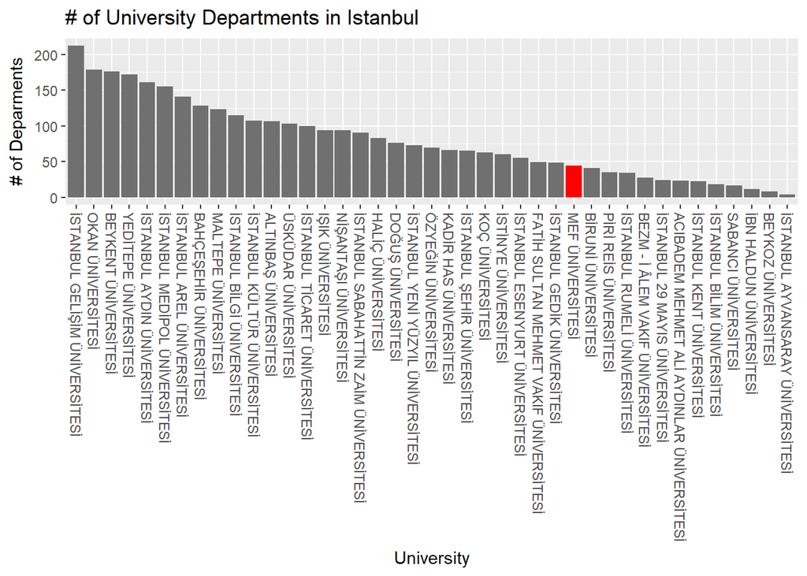

```r
ggplot(university_departments, aes(x=reorder(University_Name,-Departments), y=Departments)) +
  geom_bar(stat = "identity", aes(fill=university_departments$University_Name=='MEF ÜNİVERSİTESİ')) +
  labs(title="# of University Departments in Istanbul",x="University",y="# of Deparments",fill="") +
  theme (axis.text.x=element_text (angle=-90,vjust=0.5, hjust=0)) +
  scale_fill_manual(values = c('#707070', 'red'),guide=FALSE)
```

## Maximum Scores of Universities in Istanbul

```r
maximum_scores <- osym_data_2017 %>%
  select(University_Name=university_name, max_score, city, program_id) %>%
  filter(city=='İSTANBUL' & substr(program_id,0,1)=="2") %>%
  group_by(University_Name) %>%
  summarise(Max_Score=max(max_score)) %>%
  arrange(desc(Max_Score))

maximum_scores
```

```
## # A tibble: 41 x 2
##                              University_Name Max_Score
##                                        <chr>     <dbl>
##  1                          KOÇ ÜNÝVERSÝTESÝ  569.1112
##  2             ÝSTANBUL MEDÝPOL ÜNÝVERSÝTESÝ  559.4780
##  3 ACIBADEM MEHMET ALÝ AYDINLAR ÜNÝVERSÝTESÝ  542.3482
##  4                      SABANCI ÜNÝVERSÝTESÝ  538.7725
##  5                     YEDÝTEPE ÜNÝVERSÝTESÝ  531.3691
##  6                   BAHÇEÞEHÝR ÜNÝVERSÝTESÝ  530.4845
##  7                       BÝRUNÝ ÜNÝVERSÝTESÝ  528.6418
##  8               ÝSTANBUL AYDIN ÜNÝVERSÝTESÝ  525.5809
##  9            ÝSTANBUL 29 MAYIS ÜNÝVERSÝTESÝ  522.9686
## 10                      ÖZYEÐÝN ÜNÝVERSÝTESÝ  522.6578
## # ... with 31 more rows
```

Let’s visualize this data in a barchart.

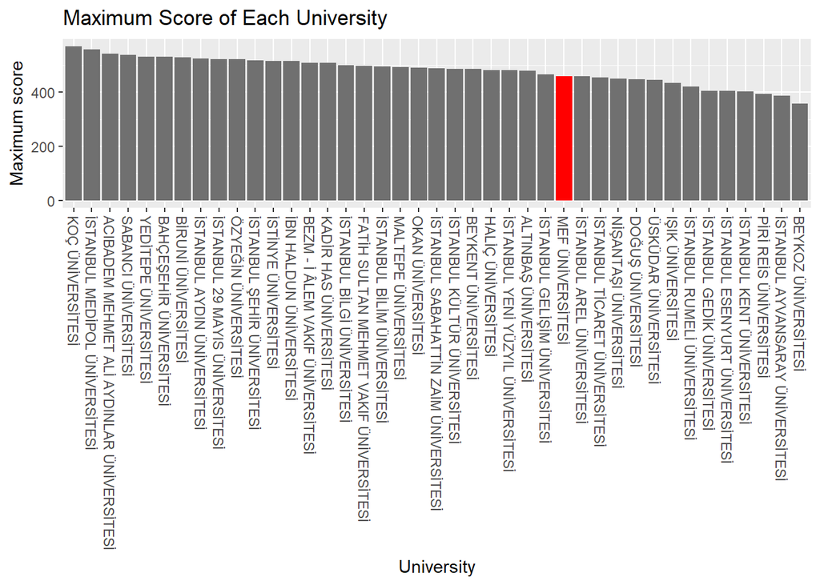

```r
ggplot(maximum_scores, aes(x=reorder(University_Name,-Max_Score), y=Max_Score)) +
  geom_bar(stat = "identity", aes(fill=University_Name=='MEF ÜNİVERSİTESİ')) +
  labs(title="Maximum Score of Each University",x="University",y="Maximum score",fill="") +
  theme (axis.text.x=element_text (angle=-90,vjust=0.5,hjust=0)) +
  scale_fill_manual(values = c('#707070', 'red'),guide=FALSE)
```

## University Department Quotas in Istanbul

```r
department_quota <- osym_data_2017 %>%
  select(University_Name=university_name,general_quota,city,program_id) %>%
  filter(city=='İSTANBUL' & substr(program_id,0,1)=="2") %>%
  group_by(University_Name) %>%
  summarise(General_Quota=sum(as.integer(general_quota))) %>%
  arrange(desc(General_Quota))

department_quota
```

```
## # A tibble: 41 x 2
##                  University_Name General_Quota
##                            <chr>         <int>
##  1 ÝSTANBUL MEDÝPOL ÜNÝVERSÝTESÝ          4495
##  2          BEYKENT ÜNÝVERSÝTESÝ          3974
##  3 ÝSTANBUL GELÝÞÝM ÜNÝVERSÝTESÝ          3950
##  4   ÝSTANBUL AYDIN ÜNÝVERSÝTESÝ          3625
##  5         YEDÝTEPE ÜNÝVERSÝTESÝ          3569
##  6       BAHÇEÞEHÝR ÜNÝVERSÝTESÝ          2843
##  7             OKAN ÜNÝVERSÝTESÝ          2506
##  8  ÝSTANBUL KÜLTÜR ÜNÝVERSÝTESÝ          2284
##  9          ÜSKÜDAR ÜNÝVERSÝTESÝ          2150
## 10          MALTEPE ÜNÝVERSÝTESÝ          2107
## # ... with 31 more rows
```

Let’s visualize this data in a barchart.

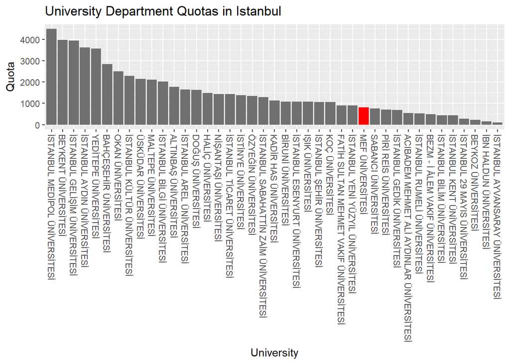

```r
ggplot(department_quota, aes(x=reorder(University_Name,-General_Quota), y=General_Quota)) +
  geom_bar(stat = "identity", aes(fill=University_Name=='MEF ÜNİVERSİTESİ')) +
  labs(title="University Department Quotas in Istanbul",x="University",y="Quota",fill="") +
  theme (axis.text.x=element_text (angle=-90,vjust=0.5,hjust=0)) +
  scale_fill_manual(values = c('#707070', 'red'),guide=FALSE)
```

## Listing Programs in MEF by scores

```r
maximum_scores <- osym_data_2017 %>%
  select(university_name,program_name,max_score) %>%
  filter(university_name=='MEF ÜNİVERSİTESİ') %>%
  group_by(program_name) %>%
  summarise(Max_Score=max(max_score)) %>%
  arrange(desc(Max_Score))

maximum_scores
```

```
## # A tibble: 44 x 2
##                                                         program_name
##                                                                <chr>
##  1                                                Hukuk (Tam Burslu)
##  2                   Ýngilizce Öðretmenliði (Ýngilizce) (Tam Burslu)
##  3                                Psikoloji (Ýngilizce) (Tam Burslu)
##  4                   Ýngilizce Öðretmenliði (Ýngilizce) (%75 Burslu)
##  5                  Bilgisayar Mühendisliði (Ýngilizce) (Tam Burslu)
##  6                    Endüstri Mühendisliði (Ýngilizce) (Tam Burslu)
##  7                      Makine Mühendisliði (Ýngilizce) (Tam Burslu)
##  8                                 Mimarlýk (Ýngilizce) (Tam Burslu)
##  9      Rehberlik ve Psikolojik Danýþmanlýk (Ýngilizce) (Tam Burslu)
## 10 Siyaset Bilimi ve Uluslararasý Ýliþkiler (Ýngilizce) (Tam Burslu)
## # ... with 34 more rows, and 1 more variables: Max_Score <dbl>
```

Let’s find Score in top %10 percentile

```r
quantile_scores <- osym_data_2017 %>%
  select(city,max_score,program_id)%>%
  filter(city=='İSTANBUL' & substr(program_id,0,1)=="2") %>%
  summarise(Quantile_Score=quantile(max_score,c(.90))) %>%
  arrange(desc(Quantile_Score))

q10 <- quantile_scores
quantile_scores
```

```
## # A tibble: 1 x 1
##   Quantile_Score
##            <dbl>
## 1       443.8652
```

Let’s visualize this data in a barchart.

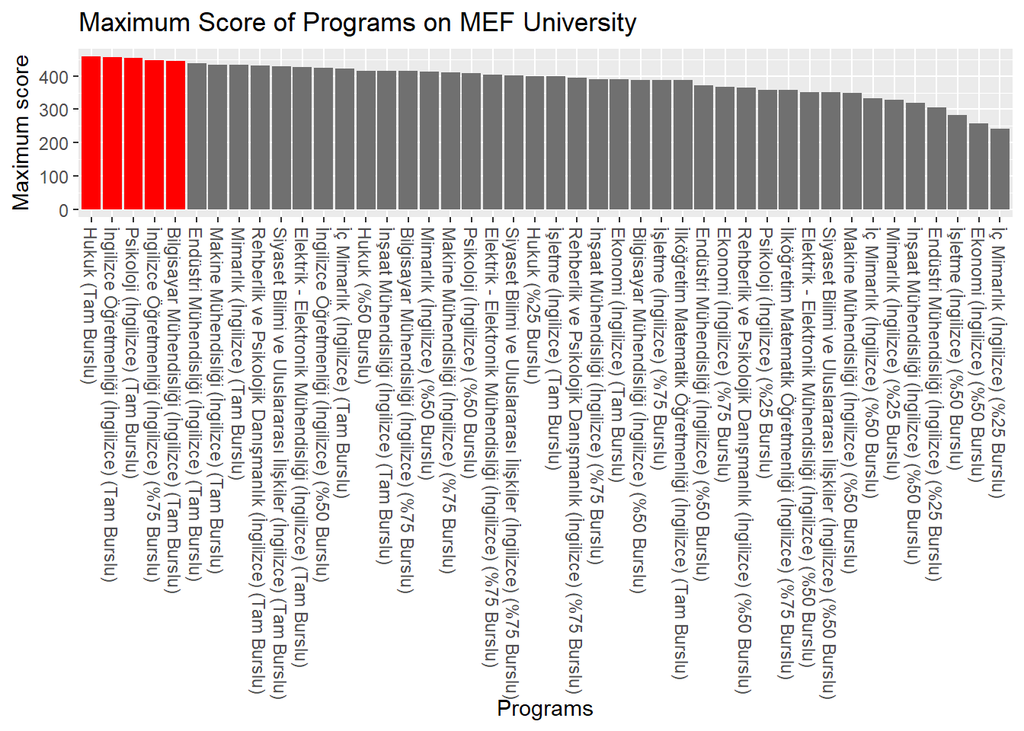

```r
ggplot(maximum_scores, aes(x=reorder(program_name,-Max_Score), y=Max_Score)) +
  geom_bar(stat = "identity", aes(fill=Max_Score>q10[[1]])) +
  labs(title="Maximum Score of Programs on MEF University",x="Programs",y="Maximum score",fill="") +
  theme (axis.text.x=element_text (angle=-90,vjust=0.5,hjust=0)) +
  scale_fill_manual(values = c('#707070',"red"),guide=FALSE)
```

## Conclusion

Our findings and suggestions to MEF University Management:

We compared MEF University with other Private/Foundation universities in Istanbul.

1. Less number of departmants compared to others => Should increase for more students by establishing new programs
2. Best students seems that they don’t prefer MEF => Should incentivize best students
3. Less department quota compared to others => Should increase for more students by increasing department quotas
4. Following departments stands for the 10% percentile among other universities: Hukuk (Tam Burslu) İngilizce Öğretmenliği Psikoloji (İngilizce) Tam Burslu İngilizce Öğretmenliği (%75 Burslu) Bilgisayar Mühendisliği (İngilizce, Tam Burslu)

These departmants mostly belong to “TM”. Should increase performance in “MF”.